# Homework_10

Emma Gagne

4/12/2021

## Question 1

Using a for loop, write a function to calculate the number of zeroes in a numeric vector. Before entering the loop, set up a counter variable counter <- 0. Inside the loop, add 1 to counter each time you have a zero in the matrix. Finally, use return(counter) for the output.

```
# -----------------------------------------------------
# FUNCTION zeroes_vector
# description: calculates the number of zeroes in a numeric vector
# inputs: vector containing numerics
# outputs: counter displaying number of zeroes in vector
#######################################################
zeroes_vector <- function(x=NULL) {
if(is.null(x)) {
  my_vec <- c(rep(0,8),1,3,5)
  my_vec <- sample(my_vec)
} # end of if statement

counter <- 0
for (i in seq_along(my_vec)) {
  if (my_vec[i]==0) {
    counter <- counter + 1
}  # end of if statement
} # end of for loop

  return(counter)
} # end of zeroes_vector
# -----------------------------------------------------
zeroes_vector()
```

```
> zeroes_vector()
[1] 8
```

## Question 2

Use subsetting instead of a loop to rewrite the function as a single line of code.

```
# -----------------------------------------------------
# FUNCTION zeroes_vec_new
# description counts the number of zeroes in a vector
# inputs: vector of any length of numerics
# outputs: counter of the number of zeroes in your vector
#######################################################
zeroes_vec_new <- function(x=NULL) {
  if(is.null(x)) {
    my_vec <- c(rep(0,8),1,3,5)
    my_vec <- sample(my_vec)
  } # end of if statement
# function body

counter <- sum((my_vec)[]==0)
return(counter)

} # end of zeroes_vec_new
# -----------------------------------------------------
zeroes_vec_new()
```

```
> zeroes_vec_new()
[1] 8
```

## Question 3

Write a function that takes as input two integers representing the number of rows and columns in a matrix. The output is a matrix of these dimensions in which each element is the product of the row number x the column number.

```
# -----------------------------------------------------
# FUNCTION product_matrix
# description: produced as matrix of given dimension which each element is the product of the row number and column number.
# inputs: two integers representing the number of rows and columns in a matrix.
# outputs: matrix of dimensions where each element is the product of the row number and column number.
#######################################################
product_matrix <- function(n=4,c=4) {
  my_mat <- matrix(NA, nrow=n, ncol=c)
  for (i in 1:nrow(my_mat)) {
    for(j in 1:ncol(my_mat)) {
      my_mat[i,j] <- i*j
    }
  }
# function body

return(my_mat)

} # end of product_matrix
# -----------------------------------------------------
product_matrix()
```

```
> product_matrix()
     [,1] [,2] [,3] [,4]
[1,]    1    2    3    4
[2,]    2    4    6    8
[3,]    3    6    9   12
[4,]    4    8   12   16
```

## Question 4

Use the code from the April 8th lecture (Randomization Tests) to design and conduct a randomization test for some of your own data. You will need to modify the functions that read in the data, calculate the metric, and randomize the data. Once those are set up, the program should run correctly calling your new functions. Also, to make your analysis fully repeatable, make sure you set the random number seed at the beginning (use either set.seed() in base R, or char2seed in the TeachingDemos package

```
# Preliminaries ----------------------------------

library(ggplot2)
library(TeachingDemos)
library(tidyverse)

# create treatment groups
trt_group <- c(rep("BoatPresent",5),rep("BoatAbsent",5))
print(trt_group)

# create response variable
z <- c(runif(5) + 10, runif(5) + 2)
print(z)

# combine vectors into a data frame
df <- data.frame(trt=trt_group,res=z)
print(df)

# look at means in the two groups
obs <- tapply(df$res,df$trt,mean)
print(obs)

# create a simulated data set

# set up a new data frame
df_sim <- df
df_sim$res <- sample(df_sim$res)
print(df_sim)
```

```
> print(df_sim)
           trt          res
1  BoatPresent 10.577345396
2  BoatPresent  2.761581767
3  BoatPresent  2.744576075
4  BoatPresent 10.619217604
5  BoatPresent 10.819899263
6   BoatAbsent  2.091363661
7   BoatAbsent 10.111471170
8   BoatAbsent  2.012691025
9   BoatAbsent 10.663341241
10  BoatAbsent  2.642229779
```

```
# look at mean in the to groups of randomized data
sim <- tapply(df_sim$res,df_sim$trt,mean)
print(sim)
```

```
> print(sim)
 BoatAbsent BoatPresent
5.504219375 7.504524021
```

```
# build functions ----------------------------------

# -----------------------------------------------------
# FUNCTION read_data
# description read in (or generate) data set for analysis
# inputs: file name (or nothing, as in this demo)
# outputs: column data frame of observed data (ID,x,y)
#######################################################
read_data <- function(z=NULL) {
  if(is.null(z)) {
    boatpresence <- 1:20
    modulation <- boatpresence + 10*rnorm(20)
    df <- data.frame(ID=seq_along(boatpresence),
                     boatpresence,
                     modulation) }
  #   df <- read.table(file=z,
  #                   header=TRUE
  #                   stringAsFactors=FALSE)

  # function body

  return(df)

} # end of read_data
# -----------------------------------------------------
 read_data()
```

```
>  read_data()
  ID boatpresence     modulation
1   1            1   9.7696530990
2   2            2  -2.7525211590
3   3            3   1.7884806480
4   4            4  -3.5537352203
5   5            5  -0.7030894334
6   6            6 -10.0723809850
7   7            7   7.9069151019
8   8            8  13.7334604997
9   9            9   6.8491163508
10 10           10   8.0266075781
11 11           11  21.3927697828
12 12           12   8.2309551878
13 13           13  -7.1300071696
14 14           14   8.4447460443
15 15           15   4.9008680920
16 16           16  12.4244161524
17 17           17  18.3184976283
18 18           18  10.5561877363
19 19           19  15.7767490353
20 20           20  18.4504645176
```

```
# -----------------------------------------------------
# FUNCTION get_metric
# description calculate metric for randomization test
# inputs: 2-column data frame for regression
# outputs: regression slope
#######################################################
get_metric <- function(z=NULL) {
  if(is.null(z)){
    boatpresence <- 1:20
    modulation <- boatpresence + 10*rnorm(20)
    z <- data.frame(ID=seq_along(boatpresence),
                     boatpresence,
                     modulation) }

  . <- lm(z[,3]~z[,2])
  . <- summary(.)
  . <- .$coefficients[2,1]
  slope <- .

  # function body

  return(slope)

} # end of get_metric
# -----------------------------------------------------
 get_metric()
```

```
>  get_metric()
[1] 0.2300918431
```

```
# -----------------------------------------------------
# FUNCTION shuffle_data
# description: randomize data for regression analysis
# inputs: 3 column data frame (ID, xvar, yvar)
# outputs: 3 column data frame (ID, xvar, yvar)
#######################################################
shuffle_data <- function(z=NULL) {
  if(is.null(z)) {
    boatpresence <- 1:20
    modulation <- boatpresence + 10*rnorm(20)
    z <- data.frame(ID=seq_along(boatpresence),
                     boatpresence,
                     modulation) }
  z[,3] <- sample(z[,3])

  # function body

  return(z)

} # end of shuffle_data
# -----------------------------------------------------
shuffle_data()
```

```
> shuffle_data()
   ID boatpresence    modulation
1   1            1  14.704674314
2   2            2   7.808632328
3   3            3 -26.401882019
4   4            4   8.891919906
5   5            5  -3.365260041
6   6            6  14.589785693
7   7            7  17.644657819
8   8            8 -10.525148793
9   9            9  20.145625436
10 10           10  11.732718181
11 11           11   7.901906191
12 12           12  15.482342638
13 13           13 -12.157678688
14 14           14  10.744447103
15 15           15  12.735180919
16 16           16  17.416509869
17 17           17  16.869511150
18 18           18  12.082383483
19 19           19  28.106809607
20 20           20   5.450240763
```

```
# -----------------------------------------------------
# FUNCTION get_pval
# description: calculate p value from simulation
# inputs: list of observed metric and vector of simulated metrics
# outputs: lower and upper tail probability value
#######################################################
get_pval <- function(z=NULL) {
  if(is.null(z)){
    boatpresence <- 1:20
    modulation <- boatpresence + 10*rnorm(20)
    z <- data.frame(ID=seq_along(boatpresence),
                    boatpresence,
                    modulation) }
    z <- list(z[,3], sample(z[,3]))
  p_lower <- mean(z[[2]]<=z[[1]])
  p_upper <- mean(z[[2]]>=z[[1]])

  # function body

  return(c(pL=p_lower,pU=p_upper))
}
# end of get_pval
# -----------------------------------------------------
get_pval()
```

```
> get_pval()
 pL  pU
0.6 0.5
```

```
# -----------------------------------------------------
# FUNCTION plot_ran_test
# description: create a ggplot of histogram of simulated values
# inputs: list of observed metrics and vector of simulated metrics
# outputs: saved ggplot graph
#######################################################
plot_ran_test <- function(z=NULL) {

  if(is.null(z)){
    z <- list(rnorm(1),rnorm(1000)) }
  df <- data.frame(ID=seq_along(z[[2]]), sim_x=z[[2]])
  p1 <- ggplot(data=df, mapping=aes(x=sim_x))
  p1 + geom_histogram(mapping=aes(fill=I("goldenrod"),
                                  color=I("black"))) +
    geom_vline(aes(xintercept=z[[1]],col="blue"))

  # function body

} # end of plot_ran_test
# -----------------------------------------------------
 plot_ran_test()
```

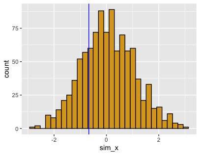

plot_ran_test

[output not shown]

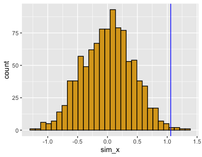

plot_ran_test_slopes

## Question 5

For comparison, calculate in R the standard statistical analysis you would use with these data. How does the p-value compare for the standard test versus the p value you estimated from your randomization test? If the p values seem very different, run the program again with a different starting seed (and/or increase the number of replications in your randomization test). If there are persistent differences in the p value of the standard test versus your randomization, what do you think is responsible for this difference?

```
# Making a fake data set
boatpresence <- 1:20
modulation <- boatpresence + 10*rnorm(20)
z <- data.frame(ID=seq_along(boatpresence),
                boatpresence,
                modulation)

# Regression analysis in R
reg_model <- lm(modulation~boatpresence, data=z) # lm means linear model

# summary has the elements that we need
summary(reg_model)

z <- unlist(summary(reg_model))

reg_stats <- list(intercept=z$coefficients1,
                  slope=z$coefficients2,
                  intercept_p=z$coefficients7,
                  slope_p=z$coefficients8, # most common for signif
                  r2=z$r.squared)
print(reg_stats)
```

```
> print(reg_stats)
$intercept
[1] 0.09406010875

$slope
[1] 0.624452425

$intercept_p
[1] 0.9891742205

$slope_p
[1] 0.2883097452

$r2
[1] 0.06236294624
```